# ㅊ0527_분류(SVM, 인공신경망, KNN, 모델평가)

## 서포트 벡터 머신

```python
# 데이터 처리
import pandas as pd
# 데이터 시각화
import matplotlib
import matplotlib.pyplot as plt

# 데이터 스케일링
from sklearn.preprocessing import StandardScaler
# 데이터 분할: train, test
from sklearn.model_selection import train_test_split
# 분류 SVM
from sklearn.svm import SVC
# 최적모델 파라미터 탐색
from sklearn.model_selection import GridSearchCV

# 분류모델 평가 함수
from sklearn.metrics import accuracy_score, f1_score
from sklearn.metrics import confusion_matrix, classification_report
```

```python
matplotlib.rc('font', family='NanumGothic')
matplotlib.rcParams['axes.unicode_minus'] = False
plt.rcParams["font.family"] = 'NanumGothic'
```

### 데이터 구성하기

```python
df_raw = pd.read_csv('../빅데이터 기초/Data/HMEQ.csv')
df_raw.isnull().sum(axis=0)
```

```
BAD          0
LOAN         0
MORTDUE      0
VALUE       14
REASON       0
JOB         81
YOJ        205
DEROG        0
DELINQ      30
CLAGE       37
NINQ        56
CLNO         0
DEBTINC      0
dtype: int64
```

```python
# fillna : 결측치를 채우는 함수
# JOB 결측치는 Other로 입력
df_raw['JOB'].fillna("Other", inplace=True)

# 숫자형 변수의 결측치는 해당 변수의 평균값 입력: ds_hmeq.mean() 각 변수별 평균 계산 후 결측치 대체
df_raw.fillna(df_raw.mean(), inplace= True)
```

```python
# get dummies : 데이터의 문자형 변수에 대한 더미변수 생성
df_raw_dummy = pd.get_dummies(df_raw)
# 더미변수 생성된 데이터의 상위 5개 row 확인
df_raw_dummy.head()
```

|  | BAD | LOAN | MORTDUE | VALUE | YOJ | DEROG | DELINQ | CLAGE | NINQ | CLNO | DEBTINC | REASON_DebtCon | REASON_HomeImp | JOB_Mgr | JOB_Office | JOB_Other | JOB_ProfExe | JOB_Sales | JOB_Self |
| --- | --- | --- | --- | --- | --- | --- | --- | --- | --- | --- | --- | --- | --- | --- | --- | --- | --- | --- | --- |
| 0 | 1 | 1700 | 30548 | 40320.0 | 9.0 | 0 | 0.0 | 101.466002 | 1.0 | 8 | 37.113614 | 0 | 1 | 0 | 0 | 1 | 0 | 0 | 0 |
| 1 | 1 | 1800 | 28502 | 43034.0 | 11.0 | 0 | 0.0 | 88.766030 | 0.0 | 8 | 36.884894 | 0 | 1 | 0 | 0 | 1 | 0 | 0 | 0 |
| 2 | 0 | 2300 | 102370 | 120953.0 | 2.0 | 0 | 0.0 | 90.992533 | 0.0 | 13 | 31.588503 | 0 | 1 | 0 | 1 | 0 | 0 | 0 | 0 |
| 3 | 1 | 2400 | 34863 | 47471.0 | 12.0 | 0 | 0.0 | 70.491080 | 1.0 | 21 | 38.263601 | 0 | 1 | 1 | 0 | 0 | 0 | 0 | 0 |
| 4 | 0 | 2400 | 98449 | 117195.0 | 4.0 | 0 | 0.0 | 93.811775 | 0.0 | 13 | 29.681827 | 0 | 1 | 0 | 1 | 0 | 0 | 0 | 0 |

```python
# 설명변수, 목표변수 데이터 구분
df_raw_x = df_raw_dummy.drop("BAD", axis = 1, inplace= False)
df_raw_y = df_raw_dummy["BAD"]

# 데이터 분할 train_test_split(X:설명변수, Y: 목표변수 , test_size = test 데이터 비율)
df_train_x, df_test_x, df_train_y, df_test_y = train_test_split(df_raw_x, df_raw_y, test_size= 0.3, random_state=1234)
print("분할 전 설명변수 데이터: ", df_raw_x.shape)
print("분할 후 설명변수 데이터: Train", df_train_x.shape, "Test", df_test_x.shape)
```

```
분할 전 설명변수 데이터:  (3748, 18)
분할 후 설명변수 데이터: Train (2623, 18) Test (1125, 18)
```

### SVC 모델 생성

```python
svm_uncustomized = SVC(random_state=1234)
svm_uncustomized.fit(df_train_x, df_train_y)
```

```
SVC(random_state=1234)
```

### SVC 모델 Parameter 변경

#### C: 규제에 대한 강도 변경

```python
#p.142
#train 및 test 정확도 결과 저장용
train_accuracy = []
test_accuracy = []

#c: 규제(0.01,0.1,1,10)
para_c = [10**c for c in range(-2,2)]

#para_c = [0.1*c for c in range(1,10)] #c 변화 구간 변경
for v_C in para_c:
    svm = SVC(C=v_C,random_state=1234)
    svm.fit(df_train_x,df_train_y)
    train_accuracy.append(svm.score(df_train_x, df_train_y))
    test_accuracy.append(svm.score(df_test_x, df_test_y))

    #데이터 테이블로 저장
df_accuracy_c = pd.DataFrame()
df_accuracy_c['C'] = para_c
df_accuracy_c['TrainAccuracy'] = train_accuracy
df_accuracy_c['TestAccuracy'] = test_accuracy
```

```python
#p.143
#C별 정확도 테이블
df_accuracy_c.round(3)
```

|  | C | TrainAccuracy | TestAccuracy |
| --- | --- | --- | --- |
| 0 | 0.01 | 0.908 | 0.908 |
| 1 | 0.10 | 0.908 | 0.908 |
| 2 | 1.00 | 0.908 | 0.908 |
| 3 | 10.00 | 0.909 | 0.908 |

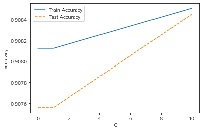

```python
#모델 정확도 그래프 확인
plt.plot(para_c,train_accuracy,linestyle='-',label = 'Train Accuracy')
plt.plot(para_c,test_accuracy,linestyle='--',label = 'Test Accuracy')
plt.ylabel('accuracy');plt.xlabel('C')
plt.legend()
```

```python
#Cost 지정
C = 0.1
```

#### Gamma: 훈련 샘플이 미치는 영향의 범위를 변경

```python
# train 및 test 정확도 결과 저장용
train_accuracy = []
test_accuracy = []

# gamma: 규제(0.01,0.1,1,10)
para_gamma = [10 ** gamma for gamma in range(-2,2)]
for i in para_gamma:
    svm = SVC(gamma = i, C=0.1, random_state=1234)
    svm.fit(df_train_x, df_train_y)
    train_accuracy.append(svm.score(df_train_x, df_train_y))
    test_accuracy.append(svm.score(df_test_x, df_test_y))

# 데이터 테이블로 저장
df_accuracy_gamma = pd.DataFrame()
df_accuracy_gamma['gamma'] = para_gamma
df_accuracy_gamma['TrainAccuracy'] = train_accuracy
df_accuracy_gamma['TestAccuracy'] = test_accuracy
```

```python
df_accuracy_gamma.round(4)
```

|  | gamma | TrainAccuracy | TestAccuracy |
| --- | --- | --- | --- |
| 0 | 0.01 | 0.9081 | 0.9076 |
| 1 | 0.10 | 0.9081 | 0.9076 |
| 2 | 1.00 | 0.9081 | 0.9076 |
| 3 | 10.00 | 0.9081 | 0.9076 |

```
<function matplotlib.pyplot.legend(*args, **kwargs)>
```

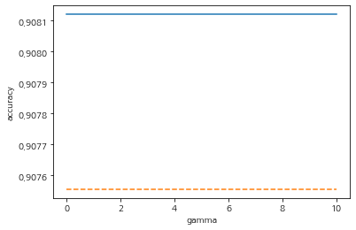

```python
plt.plot(para_gamma, train_accuracy, linestyle ='-', label = 'Train Accuracy')
plt.plot(para_gamma, test_accuracy, linestyle = '--', label = 'Test Accuracy')
plt.ylabel('accuracy')
plt.xlabel('gamma')
plt.legend
```

#### Standatdscaler: 설명변수 값의 구간을 동일하게 변경

```python
# 146
# 변수명 저장
v_feature_name = df_train_x.columns
# StandardScaler 적용
scaler = StandardScaler()
df_scaled = scaler.fit_transform(df_raw_x)
df_scaled = pd.DataFrame(df_scaled, columns=v_feature_name)
df_scaled.head()
```

|  | LOAN | MORTDUE | VALUE | YOJ | DEROG | DELINQ | CLAGE | NINQ | CLNO | DEBTINC | REASON_DebtCon | REASON_HomeImp | JOB_Mgr | JOB_Office | JOB_Other | JOB_ProfExe | JOB_Sales | JOB_Self |
| --- | --- | --- | --- | --- | --- | --- | --- | --- | --- | --- | --- | --- | --- | --- | --- | --- | --- | --- |
| 0 | -1.559587 | -0.993626 | -1.224910 | -0.017563 | -0.267462 | -0.342558 | -0.967342 | -0.018776 | -1.428350 | 0.356347 | -1.548549 | 1.548549 | -0.381873 | -0.446497 | 1.207355 | -0.574064 | -0.131804 | -0.189556 |
| 1 | -1.550817 | -1.039240 | -1.174897 | 0.251809 | -0.267462 | -0.342558 | -1.122053 | -0.666629 | -1.428350 | 0.329025 | -1.548549 | 1.548549 | -0.381873 | -0.446497 | 1.207355 | -0.574064 | -0.131804 | -0.189556 |
| 2 | -1.506968 | 0.607570 | 0.260973 | -0.960364 | -0.267462 | -0.342558 | -1.094930 | -0.666629 | -0.905133 | -0.303684 | -1.548549 | 1.548549 | -0.381873 | 2.239654 | -0.828257 | -0.574064 | -0.131804 | -0.189556 |
| 3 | -1.498198 | -0.897428 | -1.093133 | 0.386495 | -0.267462 | -0.342558 | -1.344679 | -0.018776 | -0.067985 | 0.493725 | -1.548549 | 1.548549 | 2.618672 | -0.446497 | -0.828257 | -0.574064 | -0.131804 | -0.189556 |
| 4 | -1.498198 | 0.520156 | 0.191721 | -0.690992 | -0.267462 | -0.342558 | -1.060586 | -0.666629 | -0.905133 | -0.531456 | -1.548549 | 1.548549 | -0.381873 | 2.239654 | -0.828257 | -0.574064 | -0.131804 | -0.189556 |

```python
# 데이터 분할
df_scaled_train_x, df_scaled_test_x = train_test_split(df_scaled, test_size=0.3, random_state=1234)
print("train data X size : {}".format(df_scaled_train_x.shape))
print("test data X size : {}".format(df_scaled_test_x.shape))
```

```
train data X size : (2623, 18)
test data X size : (1125, 18)
```

#### scale 조절 후 SVC 모델 재실행

```python
# Scale이 조정된 데이터로 새로운 모델 생성
svm_scaled = SVC(random_state=1234)
svm_scaled.fit(df_scaled_train_x, df_train_y)
# train 데이터 셋 정확도
print("Accuracy on training set: {:.3f}".format(svm_scaled.score(df_scaled_train_x, df_train_y)))
# test 셋 정확도
print("Accuracy on test set: {:.3f}".format(svm_scaled.score(df_scaled_test_x, df_test_y)))
```

```
Accuracy on training set: 0.944
Accuracy on test set: 0.935
```

### 새로운 SVC 모델

#### C: 규제에 대한 강도 변경

```python
#148
train_accuracy = []
test_accuracy = []

#c: 규제(0.01, 0.1, 1, 10)
para_c = [10**c for c in range(-2,2)]
for v_C in para_c:
    svm = SVC(C = v_C, random_state = 1234)
    svm.fit(df_scaled_train_x, df_train_y)
    train_accuracy.append(svm.score(df_scaled_train_x, df_train_y))
    test_accuracy.append(svm.score(df_scaled_test_x, df_test_y))

#데이터 테이블로 저장
df_accuracy_c = pd.DataFrame()
df_accuracy_c["C"] = para_c
df_accuracy_c["TrainAccuracy"] = train_accuracy
df_accuracy_c["TestAccuracy"] = test_accuracy
```

```python
df_accuracy_c.round(3)
```

|  | C | TrainAccuracy | TestAccuracy |
| --- | --- | --- | --- |
| 0 | 0.01 | 0.908 | 0.908 |
| 1 | 0.10 | 0.908 | 0.908 |
| 2 | 1.00 | 0.944 | 0.935 |
| 3 | 10.00 | 0.979 | 0.949 |

[figure not shown]

```python
#모델 정확도 그래프 확인
plt.plot(para_c, train_accuracy, linestyle = '-', label="Train Accuracy")
plt.plot(para_c, test_accuracy, linestyle = '--', label="Test Accuracy")
plt.ylabel("accuracy")
plt.xlabel("C")
plt.legend()
```

#### Gamma: 훈련 샘플이 미치는 영향의 범위를 변경 결과

```python
# train 및 test 정확도 결과 저장용
train_accuracy = []
test_accuracy = []

# gamma: 규제(0.01, 0.1, 1, 10)
para_gamma = [10 **gamma for gamma in range(-2, 2)]

for v_gamma in para_gamma:
    svm = SVC(gamma = v_gamma, C = 1, random_state=1234)
    svm.fit(df_scaled_train_x, df_train_y)
    train_accuracy.append(svm.score(df_scaled_train_x, df_train_y))
    test_accuracy.append(svm.score(df_scaled_test_x, df_test_y))

# 데이터 테이블로 저장
df_accuracy_gamma = pd.DataFrame()
df_accuracy_gamma["gamma"] = para_gamma
df_accuracy_gamma["TrainAccuracy"] = train_accuracy
df_accuracy_gamma["TestAccuracy"] = test_accuracy
```

#### 새로운 SVC 모델 평가

```python
df_accuracy_gamma.round(3)
```

|  | gamma | TrainAccuracy | TestAccuracy |
| --- | --- | --- | --- |
| 0 | 0.01 | 0.923 | 0.920 |
| 1 | 0.10 | 0.960 | 0.942 |
| 2 | 1.00 | 0.996 | 0.920 |
| 3 | 10.00 | 1.000 | 0.908 |

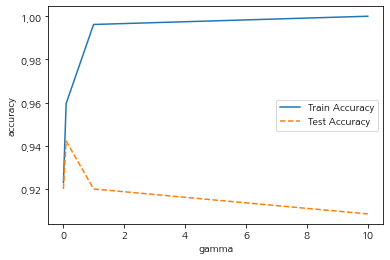

```python
plt.plot(para_gamma, train_accuracy, linestyle="-", label="Train Accuracy")
plt.plot(para_gamma, test_accuracy, linestyle="--", label="Test Accuracy")
plt.ylabel("accuracy")
plt.xlabel("gamma")
plt.legend()
```

### 결론

#### 최종 모델

```python
#p152
svc_final=SVC(gamma=0.1,C=1,random_state=1234)
svc_final.fit(df_scaled_train_x,df_train_y)
y_pred=svc_final.predict(df_scaled_test_x)
print("Accuracy on training set:{:.3f}".format(svc_final.score(df_scaled_train_x,df_train_y)))
print("Confusion matrix: \n{}".format(confusion_matrix(df_test_y,y_pred)))
print(classification_report(df_test_y,y_pred,digits=3))
```

```
Accuracy on training set:0.960
Confusion matrix:
[[1021    0]
 [  65   39]]
              precision    recall  f1-score   support

           0      0.940     1.000     0.969      1021
           1      1.000     0.375     0.545       104

    accuracy                          0.942      1125
   macro avg      0.970     0.688     0.757      1125
weighted avg      0.946     0.942     0.930      1125
```

### GridSearchCV

```python
#p153
estimator = SVC(random_state=1234)
param_grid={"C":para_c,"gamma":para_gamma}
#정확도가 높은 최적 parameter찾기
grid_rf=GridSearchCV(estimator,param_grid,scoring="accuracy",n_jobs=-1)
grid_rf.fit(df_scaled_train_x,df_train_y)
print("best estimator model: \n{}".format(grid_rf.best_estimator_))
print("\nbest parameter: \n{}".format(grid_rf.best_params_))
print("\nbest score:\n{}".format(grid_rf.best_score_.round(3)))
```

```
best estimator model:
SVC(C=10, gamma=0.1, random_state=1234)

best parameter:
{'C': 10, 'gamma': 0.1}

best score:
0.96
```

## 인공신경망

- 정의: 네트워크를기계학습과 인지과학을 통해 수학적으로 표현한 모델
- 단층 신경망: 히든 레이어 없이 하나의 입력층과 출력층만 존재하는 인공 신경망 모델
  - 층: 여러 개의 뉴런 집합
  - 뉴런의 output은 {0, 1}이거나 [0, 1] 사이의 값을 갖도록 설정
- 다층 신경망: 입력층을 제외한 층을 2개 이상 포함하는 ANN
  - 입력층과 출력층을 제외한 모든 층을 히든 레이어라고 한다.
  - 결합함수: 입력층 또는 은닉층의 마디를 결합, 대부분의 신경망은 결합함수로 선형함수 이용
  - 순/역전파: 오차(손실) 최소화를 위한 오류 역전파 및 가중치 조정
  - 은닉층(Hidden Layer) 개수와 층별 노드 개수를 지정-> 은닉층이 복잡할수록 과대적합
  - 활성화 함수: 입력층 또는 이전의 은닉층의 정보(가중 합)-> 다음 층으로의 출력값을 결정하는 함수
    - 계단
    - sigmoid(logistic)
    - tanh
    - relu
    - softmax
- 미니배치: 전체 학습 데이터를 배치 크기로 등분하여 각 배치 데이터를 순차적으로 실행하는 방법

```python
# 데이터 처리
import pandas as pd
# 데이터 시각화
import matplotlib
import matplotlib.pyplot as plt

# 데이터 스케일링
from sklearn.preprocessing import StandardScaler
# 데이터 분할: train, test
from sklearn.model_selection import train_test_split
# 분류 SVM
from sklearn.neural_network import MLPClassifier
# 최적모델 파라미터 탐색
from sklearn.model_selection import GridSearchCV

# 분류모델 평가 함수
from sklearn.metrics import accuracy_score, f1_score
from sklearn.metrics import confusion_matrix, classification_report
```

### 데이터 구성하기

```python
df_raw = pd.read_csv('../빅데이터 기초/Data/HMEQ.csv')
df_raw.isnull().sum(axis=0)
```

```
BAD          0
LOAN         0
MORTDUE      0
VALUE       14
REASON       0
JOB         81
YOJ        205
DEROG        0
DELINQ      30
CLAGE       37
NINQ        56
CLNO         0
DEBTINC      0
dtype: int64
```

```python
# fillna : 결측치를 채우는 함수
# JOB 결측치는 Other로 입력
df_raw['JOB'].fillna("Other", inplace=True)

# 숫자형 변수의 결측치는 해당 변수의 평균값 입력: ds_hmeq.mean() 각 변수별 평균 계산 후 결측치 대체
df_raw.fillna(df_raw.mean(), inplace= True)
```

```python
# get dummies : 데이터의 문자형 변수에 대한 더미변수 생성
df_raw_dummy = pd.get_dummies(df_raw)
# 더미변수 생성된 데이터의 상위 5개 row 확인
df_raw_dummy.head()
```

|  | BAD | LOAN | MORTDUE | VALUE | YOJ | DEROG | DELINQ | CLAGE | NINQ | CLNO | DEBTINC | REASON_DebtCon | REASON_HomeImp | JOB_Mgr | JOB_Office | JOB_Other | JOB_ProfExe | JOB_Sales | JOB_Self |
| --- | --- | --- | --- | --- | --- | --- | --- | --- | --- | --- | --- | --- | --- | --- | --- | --- | --- | --- | --- |
| 0 | 1 | 1700 | 30548 | 40320.0 | 9.0 | 0 | 0.0 | 101.466002 | 1.0 | 8 | 37.113614 | 0 | 1 | 0 | 0 | 1 | 0 | 0 | 0 |
| 1 | 1 | 1800 | 28502 | 43034.0 | 11.0 | 0 | 0.0 | 88.766030 | 0.0 | 8 | 36.884894 | 0 | 1 | 0 | 0 | 1 | 0 | 0 | 0 |
| 2 | 0 | 2300 | 102370 | 120953.0 | 2.0 | 0 | 0.0 | 90.992533 | 0.0 | 13 | 31.588503 | 0 | 1 | 0 | 1 | 0 | 0 | 0 | 0 |
| 3 | 1 | 2400 | 34863 | 47471.0 | 12.0 | 0 | 0.0 | 70.491080 | 1.0 | 21 | 38.263601 | 0 | 1 | 1 | 0 | 0 | 0 | 0 | 0 |
| 4 | 0 | 2400 | 98449 | 117195.0 | 4.0 | 0 | 0.0 | 93.811775 | 0.0 | 13 | 29.681827 | 0 | 1 | 0 | 1 | 0 | 0 | 0 | 0 |

```python
# 설명변수, 목표변수 데이터 구분
df_raw_x = df_raw_dummy.drop("BAD", axis = 1, inplace= False)
df_raw_y = df_raw_dummy["BAD"]

# 데이터 분할 train_test_split(X:설명변수, Y: 목표변수 , test_size = test 데이터 비율)
df_train_x, df_test_x, df_train_y, df_test_y = train_test_split(df_raw_x, df_raw_y, test_size= 0.3, random_state=1234)
print("분할 전 설명변수 데이터: ", df_raw_x.shape)
print("분할 후 설명변수 데이터: Train", df_raw_x.shape, "Test", df_test_x.shape)
```

```
분할 전 설명변수 데이터:  (3748, 18)
분할 후 설명변수 데이터: Train (3748, 18) Test (1125, 18)
```

### MLPClassifier 모델 생성

```python
# 173
nn_uncustomized = MLPClassifier(random_state = 1234)
nn_uncustomized.fit(df_train_x, df_train_y)
#train 데이터 셋 정확도
print("Accuracy on training set: {:.3f}".format(nn_uncustomized.score(df_train_x, df_train_y)))
print("Accuracy on training set: {:.3f}".format(nn_uncustomized.score(df_test_x, df_test_y)))
```

```
Accuracy on training set: 0.722
Accuracy on training set: 0.683
```

### 모델 Parameter 변경

#### Hidden Layer: 은닉층 변경

#### Activation: 활성화 함수 변경

#### Standatdscaler: 설명변수 scale 변경

```python
# 178
# 변수명 저장
v_feature_name = df_train_x.columns

# StandardScaler 적용
scaler = StandardScaler()
df_scaled = scaler.fit_transform(df_raw_x)
df_scaled = pd.DataFrame(df_scaled, columns=v_feature_name)
df_scaled.head()

# 데이터 분할
df_scaled_train_x, df_scaled_test_x = train_test_split(df_scaled, test_size=0.3, random_state=1234)
print("train data X size : {}".format(df_scaled_train_x.shape))
print("test data X size : {}".format(df_scaled_test_x.shape))
```

```
train data X size : (2623, 18)
test data X size : (1125, 18)
```

```python
# 179
# Scale이 조정된 데이터로 새로운 모델 생성
nn_scaled = MLPClassifier(random_state=1234)
nn_scaled.fit(df_scaled_train_x, df_train_y)
# train 데이터 셋 정확도
print("Accuracy on training set: {:.3f}".format(nn_scaled.score(df_scaled_train_x, df_train_y)))
# test 셋 정확도
print("Accuracy on test set: {:.3f}".format(nn_scaled.score(df_scaled_test_x, df_test_y)))
```

```
Accuracy on training set: 0.971
Accuracy on test set: 0.943
```

### 새로운 MLPClassifier 모델

#### Hidden Layer: 은닉층 변경

```python
# train test 정확도 결과
train_accuracy = []
test_accuracy = []
# hidden layer sizes : 은닉층 변경
para_hidden = [20* hidden for hidden in range(1,11)]
for v_hidden in para_hidden:
    # nn = MLPClassifier(hidden_layer_sizes = v_hidden, random_state = 1234)
    nn = MLPClassifier(hidden_layer_sizes = (v_hidden, v_hidden), random_state=1234)
    nn.fit(df_scaled_train_x, df_train_y)
    train_accuracy.append(nn.score(df_scaled_train_x, df_train_y))
    test_accuracy.append(nn.score(df_scaled_test_x, df_test_y))
# 데이터 테이블로 저장
df_accuracy_hidden = pd.DataFrame()
df_accuracy_hidden['hiddenlayer'] = para_hidden
df_accuracy_hidden['TrainAccuracy'] = train_accuracy
df_accuracy_hidden['testAccuracy'] = test_accuracy
```

```python
df_accuracy_hidden.round(3)
```

|  | hiddenlayer | TrainAccuracy | testAccuracy |
| --- | --- | --- | --- |
| 0 | 20 | 0.975 | 0.948 |
| 1 | 40 | 0.994 | 0.952 |
| 2 | 60 | 0.999 | 0.949 |
| 3 | 80 | 1.000 | 0.955 |
| 4 | 100 | 1.000 | 0.953 |
| 5 | 120 | 1.000 | 0.951 |
| 6 | 140 | 1.000 | 0.955 |
| 7 | 160 | 1.000 | 0.955 |
| 8 | 180 | 1.000 | 0.957 |
| 9 | 200 | 1.000 | 0.956 |

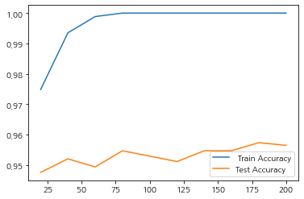

```python
# 모델 정확도 그래프 확인
plt.plot(para_hidden, train_accuracy, linestyle='-', label = ' Train Accuracy')
plt.plot(para_hidden, test_accuracy, linestyle='-', label = 'Test Accuracy')
plt.legend()
```

#### Activation: 활성화 함수 변경

```python
# p.182

#train 및 test 정확도 결과 저장용
train_accuracy = []; test_accuracy = []
#activation 변경
para_function = ['logistic','tanh','relu']

for v_function in para_function:
    nn = MLPClassifier(activation=v_function,hidden_layer_sizes = (80,80),random_state=1234)
    nn.fit(df_scaled_train_x,df_train_y)
    train_accuracy.append(nn.score(df_scaled_train_x,df_train_y))
    test_accuracy.append(nn.score(df_scaled_test_x,df_test_y))

#데이터 테이블로 저장
df_accuracy_function = pd.DataFrame()
df_accuracy_function['ActivationFunction'] = para_function
df_accuracy_function['TrainAccuracy'] = train_accuracy
df_accuracy_function['TestAccuracy'] = test_accuracy
```

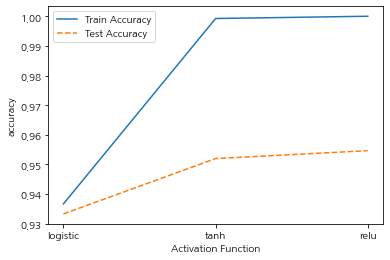

```python
# p.183

#Activation Function 별 정확도 테이블
df_accuracy_function.round(3)

#Activation Function 별 정확도 그래프 확인
plt.plot(para_function,train_accuracy,linestyle = '-',label = 'Train Accuracy')
plt.plot(para_function,test_accuracy,linestyle='--',label = 'Test Accuracy')
plt.ylabel('accuracy');plt.xlabel('Activation Function')
plt.legend()
```

#### Solver: 가중치 최적화 변경

```python
#184
train_accuracy=[];test_accuracy=[]
para_solver=['lbfgs','sgd','adam']
for v_solver in para_solver:
    nn= MLPClassifier(solver=v_solver,activation='relu',hidden_layer_sizes=(80,80),random_state=1234)
    nn.fit(df_scaled_train_x,df_train_y)
    train_accuracy.append(nn.score(df_scaled_train_x,df_train_y))
    test_accuracy.append(nn.score(df_scaled_test_x,df_test_y))
# 데이터 테이블로 저장
df_accuracy_solver=pd.DataFrame()
df_accuracy_solver["Solver"]=para_solver
df_accuracy_solver["TrainAccuracy"]=train_accuracy
df_accuracy_solver["TestAccuracy"]=test_accuracy
```

```python
#185
df_accuracy_solver.round(3)
```

|  | Solver | TrainAccuracy | TestAccuracy |
| --- | --- | --- | --- |
| 0 | lbfgs | 1.000 | 0.948 |
| 1 | sgd | 0.934 | 0.928 |
| 2 | adam | 1.000 | 0.955 |

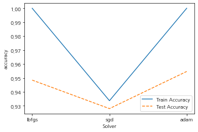

```python
#정확도 그래프 표현
plt.plot(para_solver,train_accuracy,linestyle="-",label="Train Accuracy")
plt.plot(para_solver,test_accuracy,linestyle="--",label="Test Accuracy")
plt.ylabel("accuracy");plt.xlabel("Solver")
plt.legend()
```

#### Mini Batch 변경

```python
# 186
# train 및 test 정확도 결과 저장용
train_accuracy = []
test_accuracy = []

# Mini Batch 변경
para_batch = [20 * batch for batch in range(1, 10)]

for v_batch in para_batch:
    nn = MLPClassifier(batch_size=v_batch, solver="adam", activation="relu", hidden_layer_sizes = (80, 80), random_state=1234)
    nn.fit(df_scaled_train_x, df_train_y)
    train_accuracy.append(nn.score(df_scaled_train_x, df_train_y))
    test_accuracy.append(nn.score(df_scaled_test_x, df_test_y))

# 데이터 테이블로 저장
df_accuracy_batch = pd.DataFrame()
df_accuracy_batch["Mini Batch"] = para_batch
df_accuracy_batch["TrainAccuracy"] = train_accuracy
df_accuracy_batch["TestAccuracy"] = test_accuracy
```

```python
# Mini Batch Size 별 정확도 테이블
df_accuracy_batch.round(3)
```

|  | Mini Batch | TrainAccuracy | TestAccuracy |
| --- | --- | --- | --- |
| 0 | 20 | 1.0 | 0.959 |
| 1 | 40 | 1.0 | 0.956 |
| 2 | 60 | 1.0 | 0.950 |
| 3 | 80 | 1.0 | 0.952 |
| 4 | 100 | 1.0 | 0.952 |
| 5 | 120 | 1.0 | 0.953 |
| 6 | 140 | 1.0 | 0.953 |
| 7 | 160 | 1.0 | 0.954 |
| 8 | 180 | 1.0 | 0.956 |

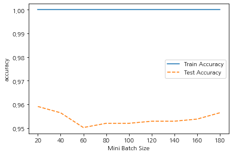

```python
# 정확도 그래프 표현
plt.plot(para_batch,train_accuracy,linestyle='-',label = 'Train Accuracy')
plt.plot(para_batch,test_accuracy,linestyle='--',label = 'Test Accuracy')
plt.ylabel('accuracy');plt.xlabel('Mini Batch Size')
plt.legend()
```

### 결론

#### 최종 모델

```python
# 188 최종모델
nn_final = MLPClassifier(hidden_layer_sizes = (80,80), activation = "relu", solver = "adam",
                         batch_size = 100, random_state =1234)
nn_final.fit(df_scaled_train_x, df_train_y)
y_pred = nn_final.predict(df_scaled_test_x)
#train 데이터 셋 정확도
print("Accuracy on train set: {:.3f}".format(nn_final.score(df_scaled_train_x, df_train_y)))
#test 데이터 셋 정확도
print("Accuracy on test set: {:.3f}\n".format(nn_final.score(df_scaled_test_x, df_test_y)))
#confusion matrix
print("Confusion matrix:\n{}".format(confusion_matrix(df_test_y,y_pred)))
#목표변수의 빈도 불균형 : f1 score로 모델평가
print(classification_report(df_test_y, y_pred, digits = 3))
```

```
Accuracy on train set: 1.000
Accuracy on test set: 0.952

Confusion matrix:
[[1018    3]
 [  51   53]]
              precision    recall  f1-score   support

           0      0.952     0.997     0.974      1021
           1      0.946     0.510     0.662       104

    accuracy                          0.952      1125
   macro avg      0.949     0.753     0.818      1125
weighted avg      0.952     0.952     0.945      1125
```

## KNN

```python
# 데이터 처리
import pandas as pd
# 데이터 시각화
import matplotlib
import matplotlib.pyplot as plt

# 데이터 스케일링
from sklearn.preprocessing import StandardScaler
# 데이터 분할: train, test
from sklearn.model_selection import train_test_split
# 분류 SVM
from sklearn.neighbors import KNeighborsClassifier
# 최적모델 파라미터 탐색
from sklearn.model_selection import GridSearchCV

import seaborn as sns

# 분류모델 평가 함수
from sklearn.metrics import accuracy_score, f1_score
from sklearn.metrics import confusion_matrix, classification_report
```

### 데이터 구성하기

```python
df_raw = pd.read_csv('../빅데이터 기초/Data/HMEQ.csv')
df_raw.isnull().sum(axis=0)
```

```
BAD          0
LOAN         0
MORTDUE      0
VALUE       14
REASON       0
JOB         81
YOJ        205
DEROG        0
DELINQ      30
CLAGE       37
NINQ        56
CLNO         0
DEBTINC      0
dtype: int64
```

```python
# fillna : 결측치를 채우는 함수
# JOB 결측치는 Other로 입력
df_raw['JOB'].fillna("Other", inplace=True)

# 숫자형 변수의 결측치는 해당 변수의 평균값 입력: ds_hmeq.mean() 각 변수별 평균 계산 후 결측치 대체
df_raw.fillna(df_raw.mean(), inplace= True)
```

```python
# get dummies : 데이터의 문자형 변수에 대한 더미변수 생성
df_raw_dummy = pd.get_dummies(df_raw)
# 더미변수 생성된 데이터의 상위 5개 row 확인
df_raw_dummy.head()
```

|  | BAD | LOAN | MORTDUE | VALUE | YOJ | DEROG | DELINQ | CLAGE | NINQ | CLNO | DEBTINC | REASON_DebtCon | REASON_HomeImp | JOB_Mgr | JOB_Office | JOB_Other | JOB_ProfExe | JOB_Sales | JOB_Self |
| --- | --- | --- | --- | --- | --- | --- | --- | --- | --- | --- | --- | --- | --- | --- | --- | --- | --- | --- | --- |
| 0 | 1 | 1700 | 30548 | 40320.0 | 9.0 | 0 | 0.0 | 101.466002 | 1.0 | 8 | 37.113614 | 0 | 1 | 0 | 0 | 1 | 0 | 0 | 0 |
| 1 | 1 | 1800 | 28502 | 43034.0 | 11.0 | 0 | 0.0 | 88.766030 | 0.0 | 8 | 36.884894 | 0 | 1 | 0 | 0 | 1 | 0 | 0 | 0 |
| 2 | 0 | 2300 | 102370 | 120953.0 | 2.0 | 0 | 0.0 | 90.992533 | 0.0 | 13 | 31.588503 | 0 | 1 | 0 | 1 | 0 | 0 | 0 | 0 |
| 3 | 1 | 2400 | 34863 | 47471.0 | 12.0 | 0 | 0.0 | 70.491080 | 1.0 | 21 | 38.263601 | 0 | 1 | 1 | 0 | 0 | 0 | 0 | 0 |
| 4 | 0 | 2400 | 98449 | 117195.0 | 4.0 | 0 | 0.0 | 93.811775 | 0.0 | 13 | 29.681827 | 0 | 1 | 0 | 1 | 0 | 0 | 0 | 0 |

```python
# 설명변수, 목표변수 데이터 구분
df_raw_x = df_raw_dummy.drop("BAD", axis = 1, inplace= False)
df_raw_y = df_raw_dummy["BAD"]

# 데이터 분할 train_test_split(X:설명변수, Y: 목표변수 , test_size = test 데이터 비율)
df_train_x, df_test_x, df_train_y, df_test_y = train_test_split(df_raw_x, df_raw_y, test_size= 0.3, random_state=1234)
print("분할 전 설명변수 데이터: ", df_raw_x.shape)
print("분할 후 설명변수 데이터: Train", df_raw_x.shape, "Test", df_test_x.shape)
```

```
분할 전 설명변수 데이터:  (3748, 18)
분할 후 설명변수 데이터: Train (3748, 18) Test (1125, 18)
```

### 모델 생성

```python
# KNN 모델 생성(default 설정)
knn_uncustomized = KNeighborsClassifier()
knn_uncustomized.fit(df_train_x, df_train_y)

# train/test 데이터 셋 정확도
print("Accuracy on training set: {:.3f}".format(knn_uncustomized.score(df_train_x, df_train_y)))
print("Accuracy on test set: {:.3f}".format(knn_uncustomized.score(df_test_x, df_test_y)))
```

```
Accuracy on training set: 0.916
Accuracy on test set: 0.908
```

#### 이웃 수 증가에 따른 정확도 변화

```python
#train 및 test 정확도 결과 저장용
train_accuracy = []
test_accuracy = []

# 최대 이웃 수: 1~15
para_n_neighbors = [i for i in range(1, 16)]

for v_n_neighbors in para_n_neighbors:
    knn = KNeighborsClassifier(n_neighbors=v_n_neighbors)
    knn.fit(df_train_x, df_train_y)
    train_accuracy.append(knn.score(df_train_x, df_train_y))
    test_accuracy.append(knn.score(df_test_x, df_test_y))

#데이터 테이블로 저장
df_accuracy_neighbors = pd.DataFrame()
df_accuracy_neighbors['Neighbors'] = para_n_neighbors
df_accuracy_neighbors['TrainAccuracy'] = train_accuracy
df_accuracy_neighbors['TestAccuracy'] = test_accuracy
```

```python
df_accuracy_neighbors.round(3)
```

|  | Neighbors | TrainAccuracy | TestAccuracy |
| --- | --- | --- | --- |
| 0 | 1 | 1.000 | 0.877 |
| 1 | 2 | 0.928 | 0.912 |
| 2 | 3 | 0.929 | 0.913 |
| 3 | 4 | 0.916 | 0.914 |
| 4 | 5 | 0.916 | 0.908 |
| 5 | 6 | 0.913 | 0.911 |
| 6 | 7 | 0.913 | 0.912 |
| 7 | 8 | 0.910 | 0.912 |
| 8 | 9 | 0.911 | 0.913 |
| 9 | 10 | 0.909 | 0.910 |
| 10 | 11 | 0.909 | 0.910 |
| 11 | 12 | 0.909 | 0.910 |
| 12 | 13 | 0.910 | 0.910 |
| 13 | 14 | 0.909 | 0.909 |
| 14 | 15 | 0.910 | 0.909 |

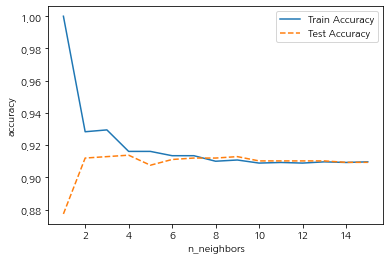

```python
#모델 정확도 그래프 확인
plt.plot(para_n_neighbors,train_accuracy,linestyle='-',label = 'Train Accuracy')
plt.plot(para_n_neighbors,test_accuracy,linestyle='--',label = 'Test Accuracy')
plt.ylabel('accuracy');plt.xlabel('n_neighbors')
plt.legend()
```

```python
n_neighbors = 4
```

#### 가중치별 이웃 수 증가에 따른 정확도 변화

```python
# train 및 test 정확도 결과 저장용
train_accuracy = []
test_accuracy = []

# 이웃 수
para_n_neighbors = [i for i in range(1, 11)] * 2

# 가중치(uniform, distance)
para_weights = (["uniform"]) * 10 + (["distance"] * 10)

# zip(list1, list2, ...)을 사용하면 list1과 list2의 인덱스별 값을 하나씩 가져옴
# 1번 loop: n_neighbors = para_n_neighbors[0], weights = para_weights[0]
# 2번 loop: n_neighbors = para_n_neighbors[1], weights = para_weights[1]
for (v_n_neighbors, v_weights) in zip(para_n_neighbors, para_weights):
    knn = KNeighborsClassifier(n_neighbors=v_n_neighbors, weights=v_weights)
    knn.fit(df_train_x, df_train_y)
    train_accuracy.append(knn.score(df_train_x, df_train_y))
    test_accuracy.append(knn.score(df_test_x, df_test_y))

# 데이터 테이블로 저장
df_accuracy_weights = pd.DataFrame()
df_accuracy_weights["Neighbors"] = para_n_neighbors
df_accuracy_weights["Weights"] = para_weights
df_accuracy_weights["TrainAccuracy"] = train_accuracy
df_accuracy_weights["TestAccuracy"] = test_accuracy
```

```python
df_accuracy_weights.round(3)
```

|  | Neighbors | Weights | TrainAccuracy | TestAccuracy |
| --- | --- | --- | --- | --- |
| 0 | 1 | uniform | 1.000 | 0.877 |
| 1 | 2 | uniform | 0.928 | 0.912 |
| 2 | 3 | uniform | 0.929 | 0.913 |
| 3 | 4 | uniform | 0.916 | 0.914 |
| 4 | 5 | uniform | 0.916 | 0.908 |
| 5 | 6 | uniform | 0.913 | 0.911 |
| 6 | 7 | uniform | 0.913 | 0.912 |
| 7 | 8 | uniform | 0.910 | 0.912 |
| 8 | 9 | uniform | 0.911 | 0.913 |
| 9 | 10 | uniform | 0.909 | 0.910 |
| 10 | 1 | distance | 1.000 | 0.877 |
| 11 | 2 | distance | 1.000 | 0.877 |
| 12 | 3 | distance | 1.000 | 0.912 |
| 13 | 4 | distance | 1.000 | 0.914 |
| 14 | 5 | distance | 1.000 | 0.913 |
| 15 | 6 | distance | 1.000 | 0.913 |
| 16 | 7 | distance | 1.000 | 0.913 |
| 17 | 8 | distance | 1.000 | 0.914 |
| 18 | 9 | distance | 1.000 | 0.915 |
| 19 | 10 | distance | 1.000 | 0.915 |

```python
# 그림을 그리기 위해 데이터의 형태롤 변환
df_accuracy_weights_pivot = df_accuracy_weights.pivot(index="Neighbors", columns="Weights", values=["TrainAccuracy", "TestAccuracy"])
df_accuracy_weights_pivot
```

| Weights Neighbors | TrainAccuracy distance | TrainAccuracy uniform | TestAccuracy distance | TestAccuracy uniform |
| --- | --- | --- | --- | --- |
| 1 | 1.0 | 1.000000 | 0.877333 | 0.877333 |
| 2 | 1.0 | 0.928326 | 0.877333 | 0.912000 |
| 3 | 1.0 | 0.929470 | 0.912000 | 0.912889 |
| 4 | 1.0 | 0.916127 | 0.913778 | 0.913778 |
| 5 | 1.0 | 0.916127 | 0.912889 | 0.907556 |
| 6 | 1.0 | 0.913458 | 0.912889 | 0.911111 |
| 7 | 1.0 | 0.913458 | 0.912889 | 0.912000 |
| 8 | 1.0 | 0.910027 | 0.913778 | 0.912000 |
| 9 | 1.0 | 0.910789 | 0.914667 | 0.912889 |
| 10 | 1.0 | 0.908883 | 0.914667 | 0.910222 |

```python
# pivot을 이용할 경우, columns와 values이 2개의 level로 이루어지므로 하나의 level로 변환
level0 = df_accuracy_weights_pivot.columns.get_level_values(0)
level1 = df_accuracy_weights_pivot.columns.get_level_values(1)
df_accuracy_weights_pivot.columns = level0 + "_" + level1
df_accuracy_weights_pivot.head()
```

| Neighbors | TrainAccuracy_distance | TrainAccuracy_uniform | TestAccuracy_distance | TestAccuracy_uniform |
| --- | --- | --- | --- | --- |
| 1 | 1.0 | 1.000000 | 0.877333 | 0.877333 |
| 2 | 1.0 | 0.928326 | 0.877333 | 0.912000 |
| 3 | 1.0 | 0.929470 | 0.912000 | 0.912889 |
| 4 | 1.0 | 0.916127 | 0.913778 | 0.913778 |
| 5 | 1.0 | 0.916127 | 0.912889 | 0.907556 |

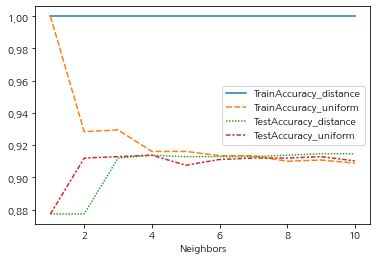

```python
sns.lineplot(data=df_accuracy_weights_pivot)
```

```python
weights = 'uniform'
```

```python
#204~206
```

## 모델 평가

- 정분류율: (TP + TN) / 전체
- 오분류율: (FN + FP) / 전체
- 민감도: TP / (TP + FN)
- 특이도: TN / (TN + FP)
- ROC 곡선: x축은 1-특이도, y축은 민감도
  - AUC: ROC 커브의 아래 부분 면적
  - AUC = 1: 완벽한 모델
  - 0.9 < AUC < 1: 매우 정확한 모델
  - 0.7 < AUC < 0.9: 정확한 모델
  - 0.5 < AUC < 0.7: 덜 정확한 모델
- F1 점수
  - 정밀도: TP / (TP + FP)
  - 재현율: TP / (TP + FN)
  - F1 점수: 2 *(정밀도* 재현율) / (정밀도 + 재현율)

```python
# 데이터 처리
import pandas as pd
# 데이터 시각화
import matplotlib
import matplotlib.pyplot as plt

import numpy as np

# 데이터 스케일링
from sklearn.preprocessing import StandardScaler
from sklearn.tree import DecisionTreeClassifier
from sklearn.ensemble import RandomForestClassifier
from sklearn.ensemble import GradientBoostingClassifier
from sklearn.neural_network import MLPClassifier

from sklearn.metrics import precision_score, recall_score, f1_score,roc_curve, auc
```

### 데이터 구성하기

```python
df_raw = pd.read_csv('../빅데이터 기초/Data/HMEQ.csv')
df_raw.isnull().sum(axis=0)
```

```
BAD          0
LOAN         0
MORTDUE      0
VALUE       14
REASON       0
JOB         81
YOJ        205
DEROG        0
DELINQ      30
CLAGE       37
NINQ        56
CLNO         0
DEBTINC      0
dtype: int64
```

```python
# fillna : 결측치를 채우는 함수
# JOB 결측치는 Other로 입력
df_raw['JOB'].fillna("Other", inplace=True)

# 숫자형 변수의 결측치는 해당 변수의 평균값 입력: ds_hmeq.mean() 각 변수별 평균 계산 후 결측치 대체
df_raw.fillna(df_raw.mean(), inplace= True)
```

```python
# get dummies : 데이터의 문자형 변수에 대한 더미변수 생성
df_raw_dummy = pd.get_dummies(df_raw)
# 더미변수 생성된 데이터의 상위 5개 row 확인
df_raw_dummy.head()
```

|  | BAD | LOAN | MORTDUE | VALUE | YOJ | DEROG | DELINQ | CLAGE | NINQ | CLNO | DEBTINC | REASON_DebtCon | REASON_HomeImp | JOB_Mgr | JOB_Office | JOB_Other | JOB_ProfExe | JOB_Sales | JOB_Self |
| --- | --- | --- | --- | --- | --- | --- | --- | --- | --- | --- | --- | --- | --- | --- | --- | --- | --- | --- | --- |
| 0 | 1 | 1700 | 30548 | 40320.0 | 9.0 | 0 | 0.0 | 101.466002 | 1.0 | 8 | 37.113614 | 0 | 1 | 0 | 0 | 1 | 0 | 0 | 0 |
| 1 | 1 | 1800 | 28502 | 43034.0 | 11.0 | 0 | 0.0 | 88.766030 | 0.0 | 8 | 36.884894 | 0 | 1 | 0 | 0 | 1 | 0 | 0 | 0 |
| 2 | 0 | 2300 | 102370 | 120953.0 | 2.0 | 0 | 0.0 | 90.992533 | 0.0 | 13 | 31.588503 | 0 | 1 | 0 | 1 | 0 | 0 | 0 | 0 |
| 3 | 1 | 2400 | 34863 | 47471.0 | 12.0 | 0 | 0.0 | 70.491080 | 1.0 | 21 | 38.263601 | 0 | 1 | 1 | 0 | 0 | 0 | 0 | 0 |
| 4 | 0 | 2400 | 98449 | 117195.0 | 4.0 | 0 | 0.0 | 93.811775 | 0.0 | 13 | 29.681827 | 0 | 1 | 0 | 1 | 0 | 0 | 0 | 0 |

```python
# 설명변수, 목표변수 데이터 구분
df_raw_x = df_raw_dummy.drop("BAD", axis = 1, inplace= False)
df_raw_y = df_raw_dummy["BAD"]

# 데이터 분할 train_test_split(X:설명변수, Y: 목표변수 , test_size = test 데이터 비율)
df_train_x, df_test_x, df_train_y, df_test_y = train_test_split(df_raw_x, df_raw_y, test_size= 0.3, random_state=1234)

print("train data X size: {}".format(df_train_x.shape))
print("train data Y size: {}".format(df_train_y.shape))
print("test data X size: {}".format(df_test_x.shape))
print("test data Y size: {}".format(df_test_y.shape))
```

```
train data X size: (2623, 18)
train data Y size: (2623,)
test data X size: (1125, 18)
test data Y size: (1125,)
```

### 분류 모델 실행

#### 평가 저장

```python
#p.226
#분석 모델
model = ['DecisionTree','RandomForest','GradientBoosting','NeuralNet']

#정확도 저장
train_accuracy = []; test_accuracy = []
#auc score 저장
model_auc = []

#Precision,Recall score 저장
model_precision = [];model_recall = []
#f1 score 저장
model_f1_score = []
```

#### 의사결정나무

```python
#p.227
#모델생성
dt_model = DecisionTreeClassifier(max_depth=4, min_samples_leaf=30)
dt_model.fit(df_train_x, df_train_y)

#train 정확도
train_accuracy.append(dt_model.score(df_train_x,df_train_y))
#test 정확도
test_accuracy.append(dt_model.score(df_test_x,df_test_y))

#예측값
y_pred = dt_model.predict(df_test_x)

#roc_curve(실제값,예측값), fpr=FP/(FP+TN) : 거짓 양성 비율, tpr = TP/(TP+FN) : 진짜 양성 비율(재현율)
fpr, tpr, thresholds = roc_curve(df_test_y, y_pred)
roc_auc = auc(fpr,tpr)

#auc 저장
model_auc.append(roc_auc)
```

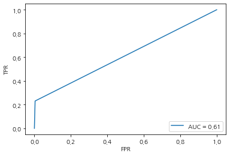

```python
# roc curve 그리기, label에 auc 표시(소수점 2자리)
plt.plot(fpr, tpr, label="AUC = %0.2f"%roc_auc)
plt.legend(loc="lower right")
plt.ylabel("TPR")
plt.xlabel("FPR")
plt.show()
```

```python
# precision, recall score
model_precision.append(precision_score(df_test_y, y_pred))
model_recall.append(recall_score(df_test_y, y_pred))

# f1 score
model_f1_score.append(f1_score(df_test_y, y_pred))
```

```python
y_pred = dt_model.predict(df_test_x)

print("Confusion matrix: \n{}".format(confusion_matrix(df_test_y, y_pred)))
print()

# 목표변수의 빈도 불균형: f1 score로 모델 평가
print(classification_report(df_test_y, y_pred, digits=3))
```

```
Confusion matrix:
[[1017    4]
 [  80   24]]

              precision    recall  f1-score   support

           0      0.927     0.996     0.960      1021
           1      0.857     0.231     0.364       104

    accuracy                          0.925      1125
   macro avg      0.892     0.613     0.662      1125
weighted avg      0.921     0.925     0.905      1125
```

#### 랜덤포레스트

```python
# 모델 생성
rf_model = RandomForestClassifier(min_samples_leaf=20, max_depth=4, n_estimators=100, random_state=1234)
rf_model.fit(df_train_x, df_train_y)

# trian/test 정확도
train_accuracy.append(rf_model.score(df_train_x, df_train_y))
test_accuracy.append(rf_model.score(df_test_x, df_test_y))

# 예측값
y_pred = rf_model.predict(df_test_x)

# roc_curve(실제값, 예측값), fpr=FP/(FP+TN): 거짓 양성 비율, tpr=TP/(TP+FN): 진짜 양성 비율(재현율)
fpr, tpr, thresholds = roc_curve(df_test_y, y_pred)
roc_auc = auc(fpr, tpr)

# auc 저장
model_auc.append(roc_auc)
```

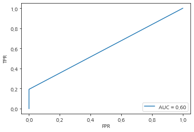

```python
#230
plt.plot(fpr, tpr, label = "AUC = %0.2f"% roc_auc)
plt.legend(loc="lower right")
plt.ylabel("TPR"); plt.xlabel("FPR")
plt.show()
```

```python
model_precision.append(precision_score(df_test_y, y_pred))
model_recall.append(recall_score(df_test_y,y_pred))

model_f1_score.append(f1_score(df_test_y, y_pred))
```

```python
y_pred = rf_model.predict(df_test_x)

print("Confusion matrix: \n{}".format(confusion_matrix(df_test_y, y_pred)))
print()

# 목표변수의 빈도 불균형: f1 score로 모델 평가
print(classification_report(df_test_y, y_pred, digits=3))
```

```
Confusion matrix:
[[1021    0]
 [  84   20]]

              precision    recall  f1-score   support

           0      0.924     1.000     0.960      1021
           1      1.000     0.192     0.323       104

    accuracy                          0.925      1125
   macro avg      0.962     0.596     0.642      1125
weighted avg      0.931     0.925     0.902      1125
```

#### 그래디언트 부스팅

```python
#231
gb_final = GradientBoostingClassifier(min_samples_leaf=10, max_depth=4, n_estimators=100, learning_rate=.1, random_state=1234)

gb_final.fit(df_train_x, df_train_y)

train_accuracy.append(gb_final.score(df_train_x, df_train_y))
test_accuracy.append(gb_final.score(df_test_x, df_test_y))

y_pred = gb_final.predict(df_test_x)

fpr, tpr, thesholds = roc_curve(df_test_y, y_pred)
roc_auc = auc(fpr, tpr)

model_auc.append(roc_auc)
```

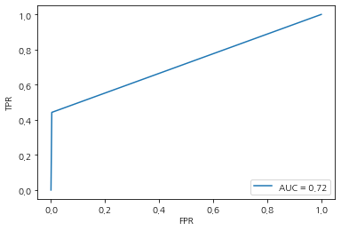

```python
# 232
# roc curve 그리기
plt.plot(fpr, tpr, label = "AUC = %0.2f"% roc_auc)
plt.legend(loc = "lower right")
plt.ylabel("TPR")
plt.xlabel("FPR")
plt.show()

# precision, recall score
model_precision.append(precision_score(df_test_y, y_pred))
model_recall.append(recall_score(df_test_y, y_pred))

model_f1_score.append(f1_score(df_test_y ,y_pred))
```

```python
y_pred = gb_final.predict(df_test_x)

print("Confusion matrix: \n{}".format(confusion_matrix(df_test_y, y_pred)))
print()

# 목표변수의 빈도 불균형: f1 score로 모델 평가
print(classification_report(df_test_y, y_pred, digits=3))
```

```
Confusion matrix:
[[1018    3]
 [  58   46]]

              precision    recall  f1-score   support

           0      0.946     0.997     0.971      1021
           1      0.939     0.442     0.601       104

    accuracy                          0.946      1125
   macro avg      0.942     0.720     0.786      1125
weighted avg      0.945     0.946     0.937      1125
```

#### 설명변수 scaling

```python
# 변수명 저장
v_feature_names = df_train_x.columns

# StandardScaler 적용
scaler = StandardScaler()
df_scaled = scaler.fit_transform(df_raw_x)
df_scaled = pd.DataFrame(df_scaled, columns=v_feature_names)

# 데이터 분할
df_scaled_train_x, df_scaled_test_x = train_test_split(df_scaled, test_size=0.3, random_state=1234)
print("train data X size : {}".format(df_scaled_train_x.shape))
print("train data Y size : {}".format(df_scaled_test_x.shape))
```

```
train data X size : (2623, 18)
train data Y size : (1125, 18)
```

#### 인공 신경망

```python
# 234p
nn_model = MLPClassifier(hidden_layer_sizes=(80,80), activation="relu", solver="adam", random_state=1234)
nn_model.fit(df_scaled_train_x, df_train_y)

train_accuracy.append(nn_model.score(df_scaled_train_x, df_train_y))
test_accuracy.append(nn_model.score(df_scaled_test_x, df_test_y))

y_pred = nn_model.predict(df_scaled_test_x)

fpr, tpr, thresholds = roc_curve(df_test_y, y_pred)
roc_auc = auc(fpr, tpr)
model_auc.append(roc_auc)
```

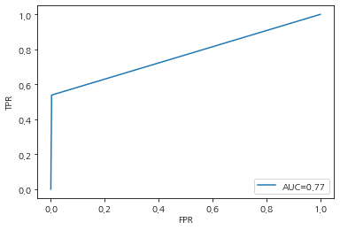

```python
# 235p
plt.plot(fpr,tpr,label="AUC=%0.2f"% roc_auc)
plt.legend(loc="lower right")
plt.ylabel("TPR");plt.xlabel("FPR")
plt.show()
```

```python
# precision, recall score
model_precision.append(precision_score(df_test_y, y_pred))
model_recall.append(recall_score(df_test_y, y_pred))

# f1_score
model_f1_score.append(f1_score(df_test_y, y_pred))
```

```python
y_pred = nn_model.predict(df_test_x)

print("Confusion matrix: \n{}".format(confusion_matrix(df_test_y, y_pred)))
print()

# 목표변수의 빈도 불균형: f1 score로 모델 평가
print(classification_report(df_test_y, y_pred, digits=3))
```

```
Confusion matrix:
[[ 54 967]
 [  4 100]]

              precision    recall  f1-score   support

           0      0.931     0.053     0.100      1021
           1      0.094     0.962     0.171       104

    accuracy                          0.137      1125
   macro avg      0.512     0.507     0.135      1125
weighted avg      0.854     0.137     0.107      1125
```

### 모델별 평가

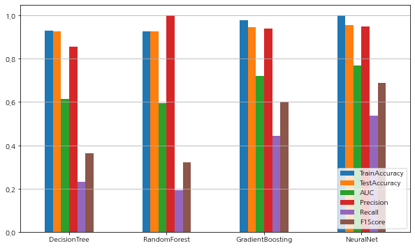

```python
#p.236
#모델별 평가 결과
df_eval = pd.DataFrame(index=model)
df_eval['TrainAccuracy'] = train_accuracy
df_eval['TestAccuracy'] = test_accuracy
df_eval['AUC'] = model_auc
df_eval['Precision'] = model_precision; df_eval['Recall'] = model_recall
df_eval['F1Score'] = model_f1_score
df_eval.round(3)

#모델별 평가 지표 확인
df_eval.plot.bar(rot = 0, figsize = (10,6))
plt.legend(loc = 'lower right')
plt.grid(axis = 'y')
```